# single_component

## Comparison with Experimental Data

Now to finally start comparing this simulation to actual data.

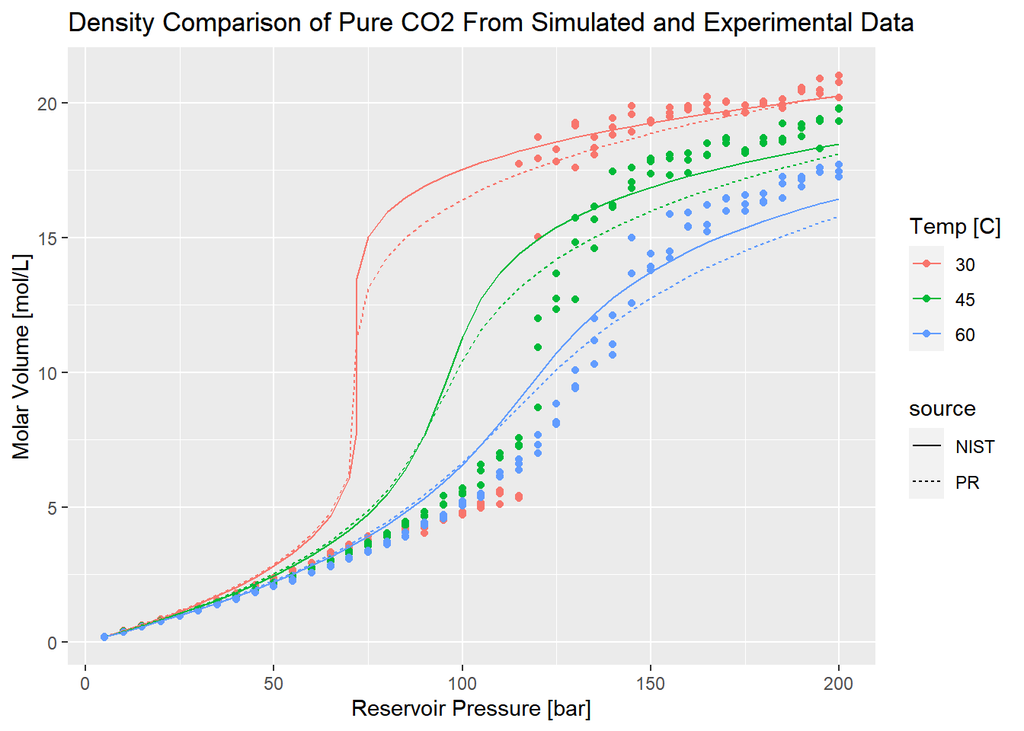

For CO2, the density comparisons perform exceptionally poorly between 80 and 130 bar at capturing the phase shift between vapor and supercritical phases. We believe this is due to the Lennard-Jones model mentioned previously. Although this area has a significant bias of underestimating density, other pressures appear to have reasonably accurate density measurements.

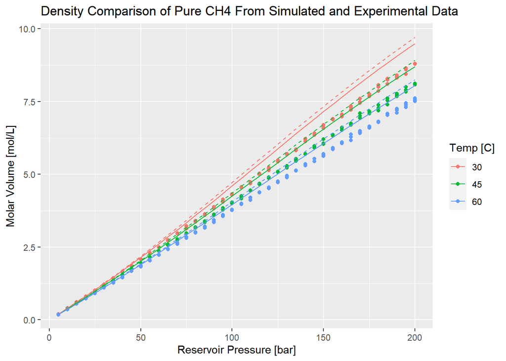

For CH4, the densities are relatively the same although there is a consistent bias underestimating the density.